# School absenteeism, SES and PM pollution

2023-02-02

With this project I will explore the relationships between school absenteeism and outdoor air pollution in the state of California, which is one of the potential locations for case studies in my dissertation.

### 1. Research questions:

1.1. How is absenteeism distributed by county in California?

1.2. How is outdoor air pollution distributed by county in California?

1.3. How is children SES distributed by county in California?

1.4. Is there a relationship between outdoor PM 2.5 air pollution, SES, and school chronic absenteeism in California counties?

### 2. Data description and sources:

2.1. California schools’ absenteeism data: I will use data of chronic absenteeism from California Department of Education of the year 2021-2022, that is publicly available here: https://www.cde.ca.gov/ds/ad/filesabd.asp. This file contains 264938 rows and 13 columns with information on Academic Year, Aggregate Level, County Code, District Code, School Code, County Name, District Name, School Name, Charter (ALL/Y/N), Reporting Category, Chronic Absenteeism Eligible, Cumulative Enrollment, Chronic Absenteeism Count, Chronic Absenteeism Rate.

According to the website chronic absenteeism rate is “The unduplicated count of students determined to be chronically absent (Chronic Absenteeism Count) divided by the Chronic Absenteeism Enrollment at the selected entity for the selected population using the available filters.”. I will use the chronic absenteeism rate of the total students of each academic institution and average it by county to create the visualizations.

2.2. Outdoor air pollution by county in California: Particulate matter of is deemed as a cause for respiratory illnesses in both children and adults. Particles of less than 2.5 μg/ m3 (respirable) can infiltrate the gas-exchange region of the lungs. PM 2.5 has been related to health effects like reduced lung function, asthma and other pulmonary diseases in children and adults who were exposed to high levels of endotoxins present in PM (Morakinyo et al., 2016). Average daily outdoor PM 2.5 air pollution by county in California is available as one of the county health rankings of the state here: https://www.countyhealthrankings.org/explore-health-rankings/california/data-and-resources

2.3 Free lunch data

This data also comes from the California department of education, at the school level. I have averaged it by county.

2.4. California counties: I found a shapefile of California counties using the tigris package.

### Reading geospatial data for California

```r
cali_co <- counties("California", cb = FALSE, resolution = "500k")
cali_co
```

```
## Simple feature collection with 58 features and 17 fields
## Geometry type: MULTIPOLYGON
## Dimension:     XY
## Bounding box:  xmin: -124.482 ymin: 32.52883 xmax: -114.1312 ymax: 42.0095
## Geodetic CRS:  NAD83
## First 10 features:
##     STATEFP COUNTYFP COUNTYNS GEOID          NAME             NAMELSAD LSAD
## 9        06      091 00277310 06091        Sierra        Sierra County   06
## 326      06      067 00277298 06067    Sacramento    Sacramento County   06
## 330      06      083 00277306 06083 Santa Barbara Santa Barbara County   06
## 347      06      009 01675885 06009     Calaveras     Calaveras County   06
## 395      06      111 00277320 06111       Ventura       Ventura County   06
## 398      06      037 00277283 06037   Los Angeles   Los Angeles County   06
## 456      06      097 01657246 06097        Sonoma        Sonoma County   06
## 539      06      031 00277280 06031         Kings         Kings County   06
```

[output cut: 24 more lines]

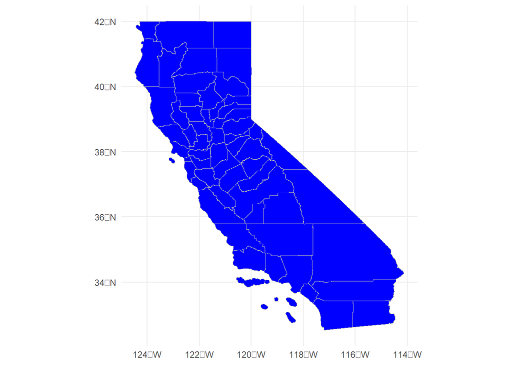

```r
cali_plan <- ggplot() +
  geom_sf(data = cali_co, color = "gray70", fill = "blue", size = 0.25) +
  theme_minimal()

cali_plan
```

### Data cleaning for absenteeism

```r
head(absent)
```

```
## # A tibble: 6 × 13
##   academic_year aggreg…¹ count…² distr…³ schoo…⁴ count…⁵ distr…⁶ schoo…⁷ chart…⁸
##   <chr>         <chr>      <int>   <int>   <int> <chr>   <chr>   <chr>   <chr>
## 1 2021-22       C              1      NA      NA Alameda ""      ""      All
## 2 2021-22       C              1      NA      NA Alameda ""      ""      No
## 3 2021-22       C              1      NA      NA Alameda ""      ""      Yes
## 4 2021-22       C              1      NA      NA Alameda ""      ""      Yes
## 5 2021-22       C              1      NA      NA Alameda ""      ""      No
## 6 2021-22       C              1      NA      NA Alameda ""      ""      All
## # … with 4 more variables: reporting_category <chr>,
## #   chronic_absenteeism_eligible_cumulative_enrollment <chr>,
## #   chronic_absenteeism_count <chr>, chronic_absenteeism_rate <chr>, and
## #   abbreviated variable names ¹aggregate_level, ²county_code, ³district_code,
## #   ⁴school_code, ⁵county_name, ⁶district_name, ⁷school_name, ⁸charter_school
```

```r
absent$chronic_absenteeism_rate <- as.numeric(absent$chronic_absenteeism_rate)
absent_co <- absent %>%
  group_by (county_name) %>%
  summarize(chronic_absent = mean(chronic_absenteeism_rate, na.rm = TRUE)) %>%
  rename(NAME = county_name)
  as_tibble()
```

```
## # A tibble: 0 × 0
```

```r
absent_co
```

```
## # A tibble: 59 × 2
##    NAME         chronic_absent
##    <chr>                 <dbl>
##  1 Alameda                34.3
##  2 Alpine                 52.9
##  3 Amador                 40.0
##  4 Butte                  39.0
##  5 Calaveras              39.2
##  6 Colusa                 30.8
##  7 Contra Costa           31.0
##  8 Del Norte              36.2
##  9 El Dorado              29.5
## 10 Fresno                 38.4
## # … with 49 more rows
```

### Data cleaning for health

```r
colnames(health)
```

```
##   [1] "fips"
##   [2] "state"
##   [3] "county"
##   [4] "unreliable"
##   [5] "deaths"
##   [6] "years_of_potential_life_lost_rate"
##   [7] "x95_percent_ci_low"
##   [8] "x95_percent_ci_high"
##   [9] "z_score"
##  [10] "ypll_rate_aian"
##  [11] "ypll_rate_aian_95_percent_ci_low"
##  [12] "ypll_rate_aian_95_percent_ci_high"
##  [13] "ypll_rate_aian_unreliable"
##  [14] "ypll_rate_asian"
##  [15] "ypll_rate_asian_95_percent_ci_low"
```

[output cut: 234 more lines]

```r
head(health)
```

```
## # A tibble: 6 × 249
##    fips state      county unrel…¹ deaths years…² x95_p…³ x95_p…⁴ z_score ypll_…⁵
##   <int> <chr>      <chr>  <chr>    <int>   <int>   <int>   <int>   <dbl>   <int>
## 1  6000 California ""     ""      378883    5679    5653    5705   NA      10423
## 2  6001 California "Alam… ""       13444    4651    4535    4766   -1.03    9654
## 3  6003 California "Alpi… "x"         NA      NA      NA      NA    0         NA
## 4  6005 California "Amad… ""         592    6930    5932    7928    0         NA
## 5  6007 California "Butt… ""        3213    7851    7436    8267    0.41   12626
## 6  6009 California "Cala… ""         744    7892    6825    8960    0.43      NA
## # … with 239 more variables: ypll_rate_aian_95_percent_ci_low <int>,
## #   ypll_rate_aian_95_percent_ci_high <int>, ypll_rate_aian_unreliable <lgl>,
## #   ypll_rate_asian <int>, ypll_rate_asian_95_percent_ci_low <int>,
## #   ypll_rate_asian_95_percent_ci_high <int>, ypll_rate_asian_unreliable <lgl>,
## #   ypll_rate_black <int>, ypll_rate_black_95_percent_ci_low <int>,
## #   ypll_rate_black_95_percent_ci_high <int>, ypll_rate_black_unreliable <lgl>,
## #   ypll_rate_hispanic <int>, ypll_rate_hispanic_95_percent_ci_low <int>, …
```

```r
health_co <- health %>%
  select(county, average_daily_pm2_5) %>%
  filter(county != "") %>%
  rename(NAME = county)

health_co
```

```
## # A tibble: 58 × 2
##    NAME         average_daily_pm2_5
##    <chr>                      <dbl>
##  1 Alameda                     14.4
##  2 Alpine                       8.3
##  3 Amador                      13.6
##  4 Butte                       13.8
##  5 Calaveras                   14.7
##  6 Colusa                      11.8
##  7 Contra Costa                13.5
##  8 Del Norte                   11.6
##  9 El Dorado                   12
## 10 Fresno                      17.1
## # … with 48 more rows
```

### Absenteeism map

```r
cali_co_absent <- left_join(cali_co, absent_co)
colnames(cali_co_absent)
```

```
##  [1] "STATEFP"        "COUNTYFP"       "COUNTYNS"       "GEOID"
##  [5] "NAME"           "NAMELSAD"       "LSAD"           "CLASSFP"
##  [9] "MTFCC"          "CSAFP"          "CBSAFP"         "METDIVFP"
## [13] "FUNCSTAT"       "ALAND"          "AWATER"         "INTPTLAT"
## [17] "INTPTLON"       "chronic_absent" "geometry"
```

```r
cali_co_absent$chronic_absent <- as.numeric(cali_co_absent$chronic_absent)

head(cali_co_absent)
```

```
## Simple feature collection with 6 features and 18 fields
## Geometry type: MULTIPOLYGON
## Dimension:     XY
## Bounding box:  xmin: -121.8626 ymin: 32.75004 xmax: -117.6464 ymax: 39.77688
## Geodetic CRS:  NAD83
##   STATEFP COUNTYFP COUNTYNS GEOID          NAME             NAMELSAD LSAD
## 1      06      091 00277310 06091        Sierra        Sierra County   06
## 2      06      067 00277298 06067    Sacramento    Sacramento County   06
## 3      06      083 00277306 06083 Santa Barbara Santa Barbara County   06
## 4      06      009 01675885 06009     Calaveras     Calaveras County   06
## 5      06      111 00277320 06111       Ventura       Ventura County   06
## 6      06      037 00277283 06037   Los Angeles   Los Angeles County   06
##   CLASSFP MTFCC CSAFP CBSAFP METDIVFP FUNCSTAT       ALAND     AWATER
## 1      H1 G4020  <NA>   <NA>     <NA>        A  2468694582   23299110
## 2      H1 G4020   472  40900     <NA>        A  2500045887   75340560
## 3      H1 G4020  <NA>  42200     <NA>        A  7080860229 2729213507
## 4      H1 G4020  <NA>   <NA>     <NA>        A  2641837359   43789489
## 5      H1 G4020   348  37100     <NA>        A  4767622161  947345735
## 6      H1 G4020   348  31080    31084        A 10513508620 1787475204
##      INTPTLAT     INTPTLON chronic_absent                       geometry
## 1 +39.5769252 -120.5219926       10.11923 MULTIPOLYGON (((-120.5559 3...
## 2 +38.4501363 -121.3443291       39.00143 MULTIPOLYGON (((-121.4399 3...
## 3 +34.5366774 -120.0383645       27.89469 MULTIPOLYGON (((-120.5823 3...
## 4 +38.1910682 -120.5541065       39.19294 MULTIPOLYGON (((-120.3762 3...
## 5 +34.3587477 -119.1331453       26.79703 MULTIPOLYGON (((-119.6361 3...
## 6 +34.1963983 -118.2618616       33.67598 MULTIPOLYGON (((-118.6782 3...
```

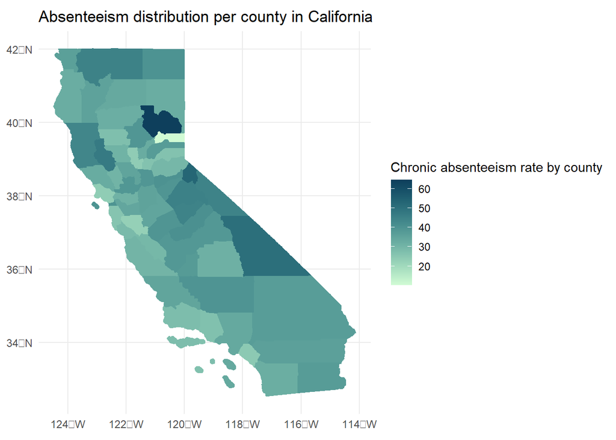

```r
cali_plan_absent <- ggplot(cali_co_absent) +
  geom_sf(aes(color = chronic_absent, fill = chronic_absent)) +
  guides(color = "none") +
  scale_fill_continuous_sequential("Dark Mint",
                                  rev = TRUE) +
                                # mid = mean(cali_co_absent$chronic_absent, na.rm = TRUE)) +
    scale_color_continuous_sequential("Dark Mint",
                                  rev = TRUE) +
                                 # mid = mean(cali_co_absent$chronic_absent, na.rm = TRUE)) +
  theme(legend.position = "bottom",
        legend.key.width = unit(2, "cm")) +
  labs(title = "Absenteeism distribution per county in California",
       fill = "Chronic absenteeism rate by county") +
  theme_minimal()


cali_plan_absent
```

### Health map with dichotomous scale showing WHO’s threshold

```r
cali_co_health <- left_join(cali_co, health_co)
colnames(cali_co_health)
```

```
##  [1] "STATEFP"             "COUNTYFP"            "COUNTYNS"
##  [4] "GEOID"               "NAME"                "NAMELSAD"
##  [7] "LSAD"                "CLASSFP"             "MTFCC"
## [10] "CSAFP"               "CBSAFP"              "METDIVFP"
## [13] "FUNCSTAT"            "ALAND"               "AWATER"
## [16] "INTPTLAT"            "INTPTLON"            "average_daily_pm2_5"
## [19] "geometry"
```

```r
cali_co_health$average_daily_pm2_5 <- as.numeric(cali_co_health$average_daily_pm2_5)

head(cali_co_health)
```

```
## Simple feature collection with 6 features and 18 fields
## Geometry type: MULTIPOLYGON
## Dimension:     XY
## Bounding box:  xmin: -121.8626 ymin: 32.75004 xmax: -117.6464 ymax: 39.77688
## Geodetic CRS:  NAD83
##   STATEFP COUNTYFP COUNTYNS GEOID          NAME             NAMELSAD LSAD
## 1      06      091 00277310 06091        Sierra        Sierra County   06
## 2      06      067 00277298 06067    Sacramento    Sacramento County   06
## 3      06      083 00277306 06083 Santa Barbara Santa Barbara County   06
## 4      06      009 01675885 06009     Calaveras     Calaveras County   06
## 5      06      111 00277320 06111       Ventura       Ventura County   06
## 6      06      037 00277283 06037   Los Angeles   Los Angeles County   06
##   CLASSFP MTFCC CSAFP CBSAFP METDIVFP FUNCSTAT       ALAND     AWATER
## 1      H1 G4020  <NA>   <NA>     <NA>        A  2468694582   23299110
## 2      H1 G4020   472  40900     <NA>        A  2500045887   75340560
## 3      H1 G4020  <NA>  42200     <NA>        A  7080860229 2729213507
## 4      H1 G4020  <NA>   <NA>     <NA>        A  2641837359   43789489
## 5      H1 G4020   348  37100     <NA>        A  4767622161  947345735
## 6      H1 G4020   348  31080    31084        A 10513508620 1787475204
##      INTPTLAT     INTPTLON average_daily_pm2_5                       geometry
## 1 +39.5769252 -120.5219926                 7.4 MULTIPOLYGON (((-120.5559 3...
## 2 +38.4501363 -121.3443291                12.8 MULTIPOLYGON (((-121.4399 3...
## 3 +34.5366774 -120.0383645                 8.6 MULTIPOLYGON (((-120.5823 3...
## 4 +38.1910682 -120.5541065                14.7 MULTIPOLYGON (((-120.3762 3...
## 5 +34.3587477 -119.1331453                10.2 MULTIPOLYGON (((-119.6361 3...
## 6 +34.1963983 -118.2618616                14.7 MULTIPOLYGON (((-118.6782 3...
```

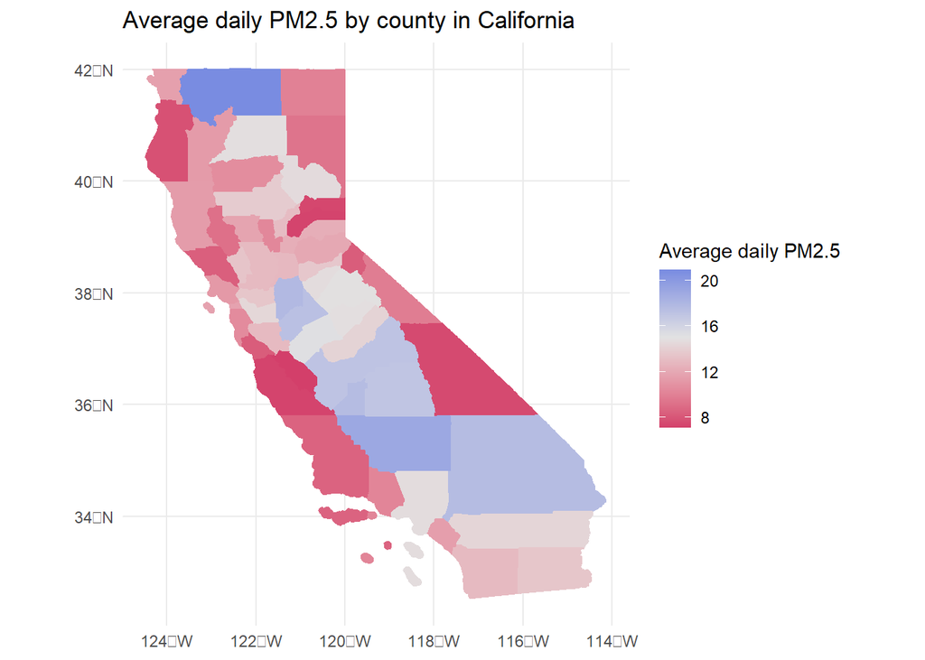

```r
cali_plan_health <- ggplot(cali_co_health) +
  geom_sf(aes(color = average_daily_pm2_5, fill = average_daily_pm2_5)) +
  guides(color = "none") +
  scale_fill_continuous_diverging ("Blue-Red 2",
                                  rev = TRUE,
                                  mid = 15) +
    scale_color_continuous_diverging ("Blue-Red 2",
                                  rev = TRUE,
                                  mid = 15) + # 15 mid is the WHO's threshold for PM 2.5 exposure
  theme(legend.position = "bottom",
        legend.key.width = unit(2, "cm")) +
  labs(title = "Average daily PM2.5 by county in California",
       fill = "Average daily PM2.5") +
  theme_minimal()


cali_plan_health
```

```r
# library("colorspace")
# hcl_palettes(plot = TRUE)
```

### Bargraph 1

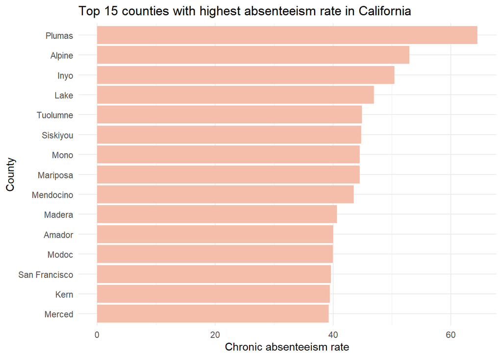

```r
cali_bar_absent <- cali_co_absent %>%
  mutate(NAME = fct_reorder(NAME, chronic_absent)) %>%
  filter(chronic_absent >= 39.2) %>%
  ggplot(aes(chronic_absent, NAME)) +
  geom_col(fill = "#F5BEAB" ) +
  labs(title = "Top 15 counties with highest absenteeism rate in California",
       x = "Chronic absenteeism rate",
       y = "County") +
  theme_minimal()

cali_bar_absent
```

### Bargraph 2

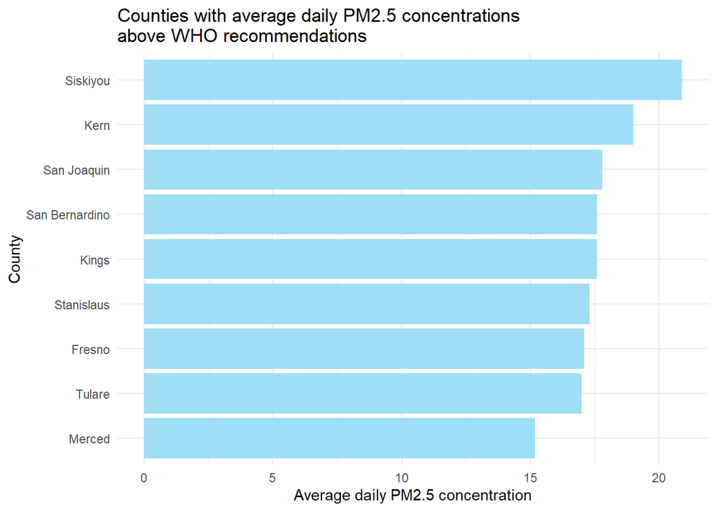

```r
cali_bar_health <- cali_co_health %>%
  mutate(NAME = fct_reorder(NAME, average_daily_pm2_5)) %>%
  filter(average_daily_pm2_5 >= 15) %>%
  ggplot(aes(average_daily_pm2_5, NAME)) +
  geom_col(fill = "#9FDFF5" ) +
  labs(title = str_wrap("Counties with average daily PM2.5 concentrations above WHO recommendations", width = 50),
       x = "Average daily PM2.5 concentration",
       y = "County") +
  theme_minimal()

cali_bar_health
```

### Free lunch data cleaning

```r
colnames(lunch)
```

```
##  [1] "academic_year"
##  [2] "county_code"
##  [3] "district_code"
##  [4] "school_code"
##  [5] "county_name"
##  [6] "district_name"
##  [7] "school_name"
##  [8] "district_type"
##  [9] "school_type"
## [10] "educational_option_type"
## [11] "nslp_provision_status"
## [12] "charter_school_y_n"
## [13] "charter_school_number"
## [14] "charter_funding_type"
## [15] "irc"
## [16] "low_grade"
## [17] "high_grade"
## [18] "enrollment_k_12"
## [19] "free_meal_count_k_12"
## [20] "percent_percent_eligible_free_k_12"
## [21] "frpm_count_k_12"
## [22] "percent_percent_eligible_frpm_k_12"
## [23] "enrollment_ages_5_17"
## [24] "free_meal_count_ages_5_17"
## [25] "percent_percent_eligible_free_ages_5_17"
## [26] "frpm_count_ages_5_17"
## [27] "percent_percent_eligible_frpm_ages_5_17"
## [28] "calpads_fall_1_certification_status"
```

```r
lunch_cali <- lunch %>%
  select(county_name, percent_percent_eligible_free_k_12) %>%
  as_tibble()

lunch_cali$percent_percent_eligible_free_k_12 <- gsub("%", "", as.character(lunch_cali$percent_percent_eligible_free_k_12))


lunch_cali$percent_percent_eligible_free_k_12 <- as.numeric(lunch_cali$percent_percent_eligible_free_k_12)

head(lunch_cali)
```

```
## # A tibble: 6 × 2
##   county_name percent_percent_eligible_free_k_12
##   <chr>                                    <dbl>
## 1 Alameda                                   78.9
## 2 Alameda                                  100
## 3 Alameda                                   75.3
## 4 Alameda                                   82.3
## 5 Alameda                                   80.2
## 6 Alameda                                   20.8
```

```r
lunch_co <- lunch_cali %>%
  group_by(county_name) %>%
  summarise(percent_percent_eligible_free_k_12 = mean(percent_percent_eligible_free_k_12)) %>%
  rename(NAME = county_name)

lunch_co
```

```
## # A tibble: 58 × 2
##    NAME         percent_percent_eligible_free_k_12
##    <chr>                                     <dbl>
##  1 Alameda                                    42.7
##  2 Alpine                                     28.6
##  3 Amador                                     42.5
##  4 Butte                                      58.4
##  5 Calaveras                                  48.9
##  6 Colusa                                     64.5
##  7 Contra Costa                               34.2
##  8 Del Norte                                  68.9
##  9 El Dorado                                  34.2
## 10 Fresno                                     66.7
## # … with 48 more rows
```

### Free lunch data

```r
cali_co_lunch <- left_join(cali_co, lunch_co)
colnames(cali_co_lunch)
```

```
##  [1] "STATEFP"                            "COUNTYFP"
##  [3] "COUNTYNS"                           "GEOID"
##  [5] "NAME"                               "NAMELSAD"
##  [7] "LSAD"                               "CLASSFP"
##  [9] "MTFCC"                              "CSAFP"
## [11] "CBSAFP"                             "METDIVFP"
## [13] "FUNCSTAT"                           "ALAND"
## [15] "AWATER"                             "INTPTLAT"
## [17] "INTPTLON"                           "percent_percent_eligible_free_k_12"
## [19] "geometry"
```

```r
#cali_co_health2$percent <- as.numeric(cali_co_health2$average_daily_pm2_5)

head(cali_co_lunch)
```

```
## Simple feature collection with 6 features and 18 fields
## Geometry type: MULTIPOLYGON
## Dimension:     XY
## Bounding box:  xmin: -121.8626 ymin: 32.75004 xmax: -117.6464 ymax: 39.77688
## Geodetic CRS:  NAD83
##   STATEFP COUNTYFP COUNTYNS GEOID          NAME             NAMELSAD LSAD
## 1      06      091 00277310 06091        Sierra        Sierra County   06
## 2      06      067 00277298 06067    Sacramento    Sacramento County   06
## 3      06      083 00277306 06083 Santa Barbara Santa Barbara County   06
## 4      06      009 01675885 06009     Calaveras     Calaveras County   06
## 5      06      111 00277320 06111       Ventura       Ventura County   06
## 6      06      037 00277283 06037   Los Angeles   Los Angeles County   06
##   CLASSFP MTFCC CSAFP CBSAFP METDIVFP FUNCSTAT       ALAND     AWATER
## 1      H1 G4020  <NA>   <NA>     <NA>        A  2468694582   23299110
## 2      H1 G4020   472  40900     <NA>        A  2500045887   75340560
```

[output cut: 18 more lines]

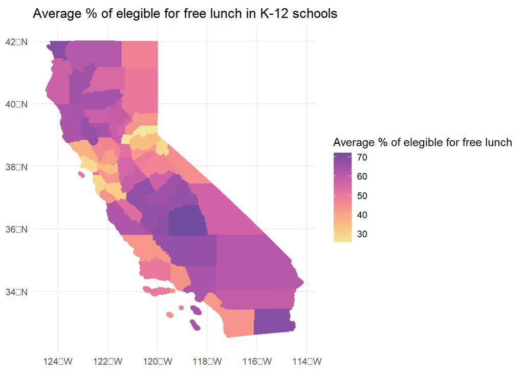

```r
cali_plan_lunch <- ggplot(cali_co_lunch) +
  geom_sf(aes(color = percent_percent_eligible_free_k_12, fill = percent_percent_eligible_free_k_12)) +
  guides(color = "none") +
  scale_fill_continuous_sequential ("Sunset",
                                  rev = TRUE) +
    scale_color_continuous_sequential ("Sunset",
                                  rev = TRUE) +
  theme(legend.position = "bottom",
        legend.key.width = unit(2, "cm")) +
  labs(title = "Average % of elegible for free lunch in K-12 schools",
       fill = "Average % of elegible for free lunch") +
  theme_minimal()


cali_plan_lunch
```

```r
# library("colorspace")
# hcl_palettes(plot = TRUE)
```

### Scatterplot relating the 3 variables

```r
plot_cor_data <- left_join(health_co, absent_co) %>%
  drop_na() %>%
  as_tibble()
head(plot_cor_data)
```

```
## # A tibble: 6 × 3
##   NAME      average_daily_pm2_5 chronic_absent
##   <chr>                   <dbl>          <dbl>
## 1 Alameda                  14.4           34.3
## 2 Alpine                    8.3           52.9
## 3 Amador                   13.6           40.0
## 4 Butte                    13.8           39.0
## 5 Calaveras                14.7           39.2
## 6 Colusa                   11.8           30.8
```

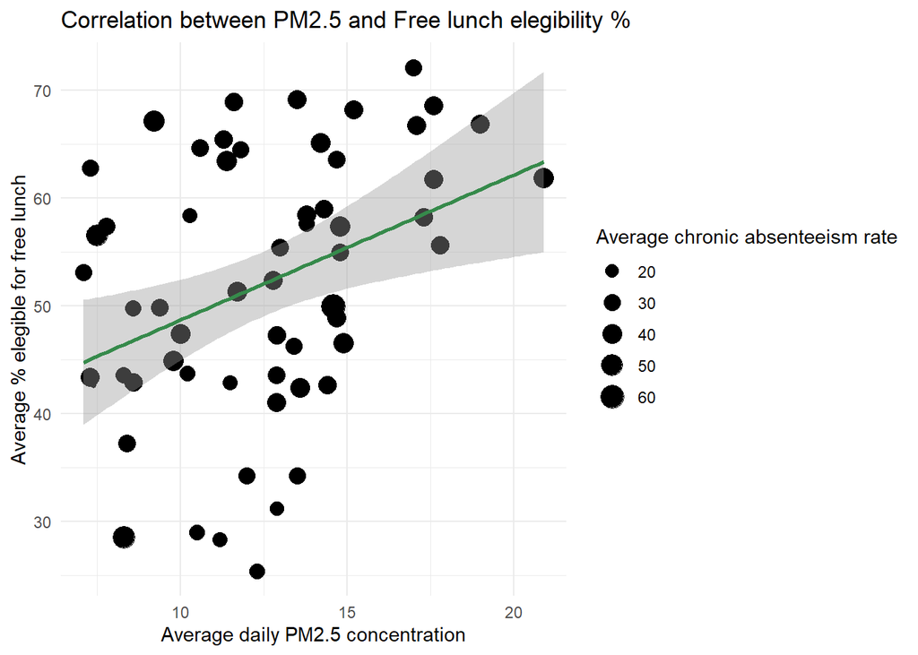

```r
plot_cor_data <- left_join(plot_cor_data, lunch_co)
plot_cor <- ggplot(plot_cor_data, aes(x = average_daily_pm2_5, y = percent_percent_eligible_free_k_12)) +
  geom_point(aes(size = chronic_absent)) +
  geom_smooth(method = lm, color = "#368A4B") +
  labs(title = "Correlation between PM2.5 and Free lunch elegibility %", x = "Average daily PM2.5 concentration", y = "Average % elegible for free lunch", size = "Average chronic absenteeism rate") +
  theme_minimal()

plot_cor
```